# Computing, Part 1

## Getting Started with R and RStudio

R is a complex, powerful statistical programming language. It’s also free! I use R to do all my empirical and methodological work. I use R to estimate statistical models, perform simulation studies, and draw graphics.

R works by scripts. The user writes a program called a “script”" and R executes the program. This might intimidate you a little. That’s okay. It’s easier than it sounds and I’m here to help you.

We’ll learn a lot about R this semester, but we’ll learn only *some* aspects of R. If you want to learn more, then see some of the resources below.

Rather than use R directly, though, we’ll use RStudio to manage and run our R programs. RStudio is simply a way to organize our R code. I use RStudio for all my R programming. I even use RStudio to write documents and make presentations using R Markdown.

To get started, you need to download the software. It’s all free.

- [Download R.](https://cran.rstudio.com)
- [Download RStudio.](https://www.rstudio.com/products/rstudio/download/)

## R as a Calculator

To get started with R, just open up RStudio and look around. If you want, you can use R like a calculator–just type directly into the console as you would a calculator.

[figure not shown]

```r
2 + 2
```

```
## [1] 4
```

```r
2*3
```

```
## [1] 6
```

```r
2^3
```

```
## [1] 8
```

```r
2/3
```

```
## [1] 0.6666667
```

```r
exp(3)
```

```
## [1] 20.08554
```

```r
log(2)
```

```
## [1] 0.6931472
```

```r
sqrt(2)
```

```
## [1] 1.414214
```

## Scripts

Ultimately, we’ll want to write all of our code in scripts so that we can modify and re-run as needed. From now on, almost everything we do will go in a script, which we can run at any point. The idea is not to do an analysis, but to write a script that can do an analysis.

[figure not shown]

To open a new R script, click “File”, “New File”, “R Script.” You can type lines of code directly into this script. In the upper-right corner of the script window, you’ll see a “Run” button. This runs the entire line that the cursor is currently on *or* all the highlighted lines. This is equivalent to Command + Enter (or Control + Enter on Windows). Unless the script takes a long time to run (and I don’t think any of ours will), I recommend hitting Command + A (or Control + A on Windows) to highlight the entire script and then Command + Enter (Control + Enter on Windows) to run *the entire script*. You need to get into the habit of running the entire script, because you want to entire script to work in one piece when you are done. It is much easier to do this if you’re running the entire script all along.

To save this script, simply click “File” and “Save.” I discuss *where* to save files a little later, but for now, just realize that R scripts will have a `.R` extension, such as `my-script.R` or `important-analysis.R`.

### Importance

Doing your work in a script is important. You might have done some statistical analysis before or at least manipulated data with Excel. Most likely you went though several steps and perhaps ended with a graph. That’s fantastic, but there are several problems.

1. If you want to re-do your analysis, you must go through the whole process again.
2. You might forget what you did. (I shouldn’t say might–you *will* forget.)
3. You cannot easily show others what you did.
4. You cannot make small changes to your analysis without going through the whole process again.

Scripting solves each of these problems.

1. If you want to re-do your analysis, just open your script and click “Run.”
2. If you forget what you did, just look at your script.
3. If you want to show others exactly what you did, just show them your script.
4. If you want to make a small change to your analysis, just make a small change to your script and click “Run.”

Scripting might seem like a lot more work. At first, it will be more work. By the end of the semester, it will be less work. As part of the paper you’ll write for this class, you’ll write a script. You’ll thank me by the end of the class.

### Comments

You can also insert comments into R scripts. This is very important, especially when you are first learning to program. To insert a comment, simply type a hashtag `#` anywhere in the code. Anything on that line after the hashtag will be ignored. I’ll always carefully comment my R code, and I’ll be even more careful about it for this class. Here’s an example of some commented code for the previous example.

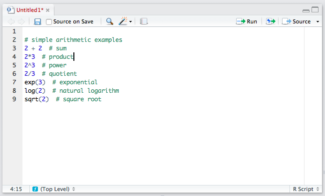

## Object-Oriented Programming

But R is much more powerful than a simple calculator, partly because it allows object-oriented programming. You can store things as “objects” to reference later. Just about anything can be stored as an object, including variables, data sets, functions, numbers, and many others.

### Scalars

Let’s start with a single number, sometimes called a “scalar.” Let’s create an object `b` that “holds” the number two. To do this, we simply use the assignment operator `<-`, which we read as “gets.”

```r
b <- 2 # read as "b gets 2"
```

We can be very creative with naming objects. Rather than `b`, we could have used `myobject`, `myObject`, `my.object`, or `my_object`. From a style perspective, I prefer `my_object` or `important_variable`. In general though, you want to give objects descriptive names so that you code is easy to read, but short names so that the code is compact.

We can now repeat some of the calculations from above, using `b` instead of two. Given that you know `b` equals two, check that the following calculations make sense.

```r
b + 3
```

```
## [1] 5
```

```r
b*3
```

```
## [1] 6
```

```r
b^3
```

```
## [1] 8
```

```r
3^b
```

```
## [1] 9
```

```r
b/3
```

```
## [1] 0.6666667
```

```r
exp(b)
```

```
## [1] 7.389056
```

```r
log(b)
```

```
## [1] 0.6931472
```

```r
sqrt(b)
```

```
## [1] 1.414214
```

You might that it would be easier to just use `2` rather than `b`, and, in the previous example, it would be. But we’ll be doing more complicated calculations. Rather than `b` holding scalars, it might hold huge data sets. Rather than applying a simple function, we might apply many functions.

### Functions

So what is a function? in the above examples `exp()`, `log()`, and `sqrt()` are functions. Importantly, functions are followed immediately by parentheses (i.e., “()”, not “[]” or “{}”, which have different meanings). “Arguments” are supplied in the functions that tell the function what to do.

You probably didn’t think about it at the time, but you can use many different bases when taking a logarithm. What base did we use when we ran `log(b)`? To see this, let’s open the help file.

```r
help(log) # or, equivalently ?log
```

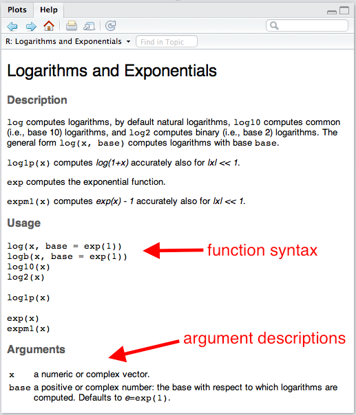

The section “Usage” shows the typical function syntax. The `log()` function takes up to two arguments. The first argument `x` is a “numeric vector.” We’ll talk more specifically about numeric vectors below, but for now, we can consider a scalar as a vector. If we provide the arguments in the same order that the appear in the functions in the “Usage” section, then we do not have to name the argument, but we still can. For example, `log(b)` and `log(x = b)` are equivalent.

You’ll also see from the help file that the default that default is `base = exp(1)`, where `exp(1)` is just the number $e$, the base of the natural log. This means that if you don’t specify `base`, it will use `base = exp(1)`.

```r
log(b) # natural log
```

```
## [1] 0.6931472
```

```r
log(b, base = exp(1)) # also natural log
```

```
## [1] 0.6931472
```

```r
log(b, base = 10) # base-10 log
```

```
## [1] 0.30103
```

```r
log(b, 10) # also a base-10 log
```

```
## [1] 0.30103
```

Notice that if we put the arguments in the proper order, we do not have to name the argument, so that `log(b, base = 10)` is equivalent to `log(b, 10)`. However, the meaning of `log(b, base = 10)` is more clear, so I prefer that approach.

But if we can only work with single numbers, we won’t get very far.

### Vectors

When we do statistical computing, we’ll usually want to work with collections of numbers (or collections of character strings, like `"Republican"` or `"Male"`).In an actual problem, the collection might contain thousands or millions of numbers. Maybe these are survey respondents’ ages or hourly stock prices over the last few years. Maybe they are a respondents sex (i.e., `"Male"` or `"Female"`) or party identification (i.e., `"Republican"`, `"Democrat"`, `"Independent"`, or `"Other"`).

We’ll call this collection of numbers or character strings a “vector” and we’ll refer to the number of elements in the vectors as the “length” of the vector. We can create a vector using the “collect” function `c()`.

There are several types of vectors, classified by the sort of elements they contain.

- `numeric`: contain numbers, such as 1.1, 2.4, and 3.4. Sometimes numeric variables are subdivided into `integer` (whole numbers, e.g., 1, 2, 3, etc.) and `double` (fractions, e.g., 1.47, 3.35462, etc.).
- `character`: contain character strings, such as `"Republican"` or `"Argentina (2001)"`.
- `factor`: contain character strings, such as `"Very Liberal"`, `"Weak Republican"`, or `"Female"`. Similar to `character`, except the entire set of possible levels is defined.
- `logical`: contain `TRUE` and/or `FALSE`.

#### Numeric Vectors

Rather than the scalar `2`, for example, we might want to work with the collection `2`, `5`, `9`, `7`, and `3`. Let’s assign the collection above to the object `a`.

```r
a <- c(2, 5, 9, 7, 3)
```

If we want to look at the object `a`, we need to enter `a` on a line by itself. This will print the object `a` for us to inspect. But since we only need to check this once, maybe we just type it in the console instead of including it in the script.

```r
a
```

```
## [1] 2 5 9 7 3
```

We can now apply functions to the vector `a` just like we did for the scalar `b`. In each case, the function is applied to each element of the vector.

```r
a + 3
```

```
## [1]  5  8 12 10  6
```

```r
a*3
```

```
## [1]  6 15 27 21  9
```

```r
a^3
```

```
## [1]   8 125 729 343  27
```

```r
3^a
```

```
## [1]     9   243 19683  2187    27
```

```r
a/3
```

```
## [1] 0.6666667 1.6666667 3.0000000 2.3333333 1.0000000
```

```r
exp(a)
```

```
## [1]    7.389056  148.413159 8103.083928 1096.633158   20.085537
```

```r
log(a)
```

```
## [1] 0.6931472 1.6094379 2.1972246 1.9459101 1.0986123
```

```r
log(a, base = 10)
```

```
## [1] 0.3010300 0.6989700 0.9542425 0.8450980 0.4771213
```

```r
sqrt(a)
```

```
## [1] 1.414214 2.236068 3.000000 2.645751 1.732051
```

```r
# sum() adds all the elements together
sum(a)
```

```
## [1] 26
```

So far, we’ve only used numeric vectors–vectors that contain numbers. But we can create and work with other types of vectors as well. For now, let’s just illustrate two types: vectors of character strings and logical vectors.

#### Character Vectors

Character strings are simply letters (or numbers, I suppose) surrounded by quotes, such as `"Republican"` or `"Male"`. If we put `c()` (i.e., “combine”) together multiple character strings, then we have a character vector.

```r
# create character vector
x <- c("Republican", "Democrat", "Republican", "Independent")

# print x
x
```

```
## [1] "Republican"  "Democrat"    "Republican"  "Independent"
```

```r
# for fun, try to multiple x times 3
x*3  # doesn't work
```

```
## Error in x * 3: non-numeric argument to binary operator
```

A Comment about Escapes: Inside a string (i.e., text surrounded by quotes, e.g., `"Male"`), a blackslash `\` is considered an “escape.” For example `\n` represents new line and `\t` represents tab.

```r
# new line
cat("Repub\nlican")
```

```
## Repub
## lican
```

```r
# tab
cat("Demo\tcrat")
```

```
## Demo crat
```

This is important because filenames are sometimes represented with back-slashes, such as `data\nominate.csv`. If entered this way, R will not read the data properly, because it treats `\n` as an escape and tries to put a new line there.

The solution is to use two back-slashes to represent one (e.g., `data\\nominate.csv`). Or you can use a forward-slash `/` instead (e.g., `data/nominate.csv`). Note that Mac uses forward-slashes in file names by default, so it might not come up. For Windows users, though, you need to use either double back-slashes or switch to forward slashes.

#### Factor Vectors

A factor vector is much like a character vector, but can only take on predefined values. While we might use a character vector to encode a variable that can have a variety of values (e.g., respondent’s name), we might use a factor to encode a variable that can take on a finite set of values, such as party identification (e.g., “Republican,” “Independent,” “Democrat,” “Other”). We refer to the possible values of a factor as the “levels.”

Creating a factor is more tricky than creating a numeric or character vector. We might take several approach, but I suggest the following two-step approach:

1. Create a character vector containing the information using `c()`.
2. Add the levels using the `factor` function.

Factor vectors have two particular advantages over character vectors.

1. It allows us to easily see when one category has zero observations.
2. It allows us to control the order in which the categories appear. This will be useful, even for unordered categorical variables.

```r
# create a character vector
pid <- c("Republican", "Democrat", "Republican", "Other")

# check type
class(pid)
```

```
## [1] "character"
```

```r
# table pid
table(pid) # two problems: 1-weird order; 2-"Independent" missing
```

```
## pid
##   Democrat      Other Republican
##          1          1          2
```

We can fix these two problems by using a factor vector instead.

```r
# create a factor vector in two steps
## create a character vector
pid <- c("Republican", "Democrat", "Republican", "Other")
## add levels using factor()
pid <- factor(pid, levels = c("Republican",
                              "Independent",
                              "Democrat",
                              "Other"))

# check type
class(pid)
```

```
## [1] "factor"
```

```r
# table pid
table(pid) # two problems fixed
```

```
## pid
##  Republican Independent    Democrat       Other
##           2           0           1           1
```

You can see that by creating a factor variable that contains the level information, we can see that we have no Independents in our sample of four respondents. We can also control the ordering of the categories.

#### Logical Vectors

Logical vectors contain elements that are true or false. R has a special way to represent true and false elements. R uses `TRUE` (without quotes) to represent true elements and `FALSE` (again, without quotes) to represent false elements. To create a logical vector, we can `c()` together a series of `TRUE`’s and/or `FALSE`’s.

```r
# create character vector
x <- c(TRUE, TRUE, FALSE, TRUE, FALSE)

# print x
x
```

```
## [1]  TRUE  TRUE FALSE  TRUE FALSE
```

```r
# for fun, try to multiple x times 3
x*3  # this works! what happens?
```

```
## [1] 3 3 0 3 0
```

## Missing Values

Missing data are extremely common in statistics. For example, a survey respondent might refuse to reveal her age or income. Or we might not know the GDP or child mortality rate for a particular country in a particular year. In R, we can represent these values with `NA` (“not available”). Notice that `NA` does not have quotes. How these values are handled depend on the function. For some function will drop missing values (for example, computing a statistic using the non-missing data) and other functions will fail. Most of the simple functions that we’ll use a first will fail by default (e.g., `sum()`, `mean()`), but many of the more complicated functions we’ll use later (e.g., `lm()`) will drop missing values.

```r
x <- c(1, 4, 3, NA, 2)
log(x) # doesn't fail: computes the log for observed data, returns NA for missing data
```

```
## [1] 0.0000000 1.3862944 1.0986123        NA 0.6931472
```

```r
sum(x) # fails: can't know the sum without know the value of the missing data
```

```
## [1] NA
```

```r
sum(x, na.rm = TRUE)  # doesn't fail: setting na.rm = TRUE tell the function to drop the missing data
```

```
## [1] 10
```

### Setting the Working Directory

Each project you work on should have it’s own directory (i.e., folder). For example, I have a folder for each class I teach and each paper I write. I have code and data for each class I teach and each paper I write. At the beginning of my R session, I simply set the working directory to the directory for the class or paper that I want to work on. To set the working directory in RStudio, click “Session,” “Set Working Directory,” “Choose Directory.” Then naviagte to and choose the directory of the project (e.g., class or paper) you want to work on.

But what should a project folder look like? It should be very well organized. I recommend you have two for this class, one for the class material (e.g., notes, data, code, etc.) and another for the paper you’ll write. I recommend something like the following structure for the class directory.

```
class-folder
  |--data
  |--notes
  |--R
  |--readings
```

You can name `class-folder` anything you like, but I recommend not using spaces. You can include other subdirectories as you like, but the important point is to have a `data` subdirectory in which you keep all the data that you load into R. The directory `R` holds all your R code for the class, named informatively (e.g., `intro-to-R.R`, `histograms.R`). You can keep any notes in the `notes` directory and any readings in the `readings` directory.

And I recommend something like the following for your papers.

```
project-folder
  |--data
  |--R
  |--doc
    |--figs
  |--lit
```

Again, name `project-folder` something short and descriptive, avoiding spaces. As before, the `data` directory holds the data for your project, the `R` directory holds all the R scripts. The `doc` directory holds the paper, perhaps in Microsoft Word or whatever you use to write papers. I recommend keeping the figures in a separate directory `figs` inside the `doc` directory. You might use a directory `lit` to keep up with any literature you reference as part of your project.

## How We’ll Always Use R

1. Start RStudio.
2. Set the working directory to whatever project you want to work on.
3. Open a new R script to do something new *OR* open a previously saved script to continue making progress.

## Other Tips

1. While you can run one line at a time (Command + Enter to run the line your curser is on), it is usually better to re-run the whole script (Command + A, then Command + Enter). Why? When you’re done, *you want the whole script to work.* You want all the code to work together. The best way to catch errors is to re-run the entire script when you make a change. If you are struggling with a specific line, it’s fine to run only that line until it works. But then be sure to run the whole script and make sure that it works as well.